# HiChIPdb tutorial

# 1 Initialization

- We loaded necessary Python packages which were used for the data analysis.

```python
import numpy as np
import matplotlib.pyplot as plt
import seaborn as sns
import pandas as pd
from pyfasta import Fasta
from scipy.stats import mannwhitneyu
```

## 1.1 Loading data

- The number of loops of H3K27ac GM12878 cell line with 5k resolution is **827288**. The data of `loop_info.csv` could be downloaded from [DOWNLOAD](http://health.tsinghua.edu.cn/hichipdb/download/fithichip_5k/all_info/loop_info.tar.gz) page.

```python
df_all_loops = pd.read_csv('loop_info.csv', header=0)
df_gm12878_loops = df_all_loops.loc[(df_all_loops['cellLine'] == 'GM12878') & (df_all_loops['ChIP'] == 'H3K27ac')]
df_gm12878_loops.head()
```

```
##    id  anchor1ID             anchor1  ...  organ cellLine      pipeline
## 0   0     166304  chr1:710000-715000  ...  Blood  GM12878  fithichip_5k
## 1   1     166304  chr1:710000-715000  ...  Blood  GM12878  fithichip_5k
## 2   2     166304  chr1:710000-715000  ...  Blood  GM12878  fithichip_5k
## 3   3     166304  chr1:710000-715000  ...  Blood  GM12878  fithichip_5k
## 4   4     166304  chr1:710000-715000  ...  Blood  GM12878  fithichip_5k
##
## [5 rows x 21 columns]
```

# 2 Length distribution

- The length of loop in H3K27ac GM12878 cell line is between 20~2000 kb.

```python
df_gm12878_loops['Distance (kb)'] = (df_gm12878_loops['anchor2'].apply(lambda x: int(x.split('-')[1]))-
                                     df_gm12878_loops['anchor1'].apply(lambda x: int(x.split('-')[1])))/1000
```

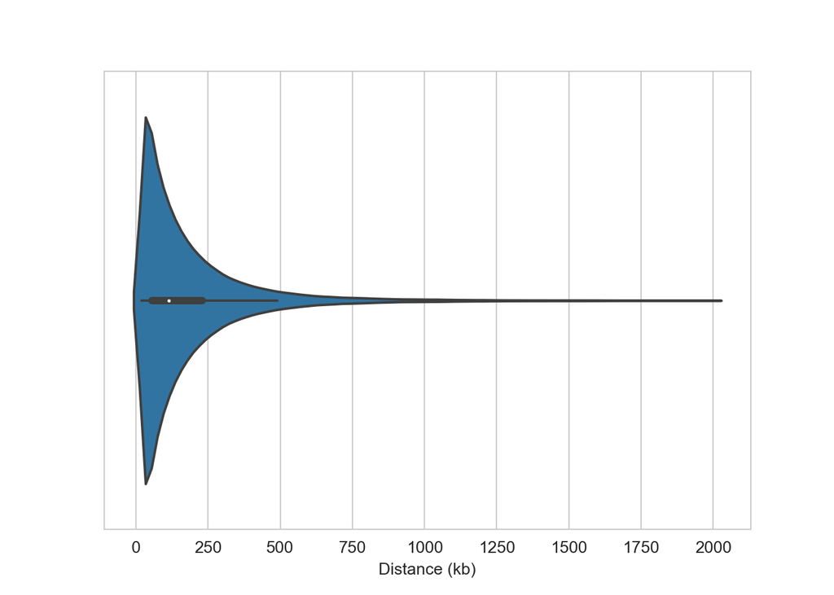

```python
sns.set_style("whitegrid")
#print(min(df_gm12878_loops['Distance (kb)']),max(df_gm12878_loops['Distance (kb)']))
ax = sns.violinplot(x=df_gm12878_loops["Distance (kb)"])
plt.show()
```

# 3 Coding gene distance

## 3.1 Preparing annotation data

- The coding gene information was downloaded from [GENCODE](https://www.gencodegenes.org/human/release_19.html#).

```bash
#wget https://ftp.ebi.ac.uk/pub/databases/gencode/Gencode_human/release_19/gencode.v19.annotation.gtf.gz && gunzip gencode.v19.annotation.gtf.gz
```

- Extracting the information of protein coding gene

```python
df_hg19 = pd.read_csv('gencode.v19.annotation.gtf', header=None,
                    sep='\t', skiprows=5, on_bad_lines='skip')
df_coding_genes = df_hg19.loc[(df_hg19[2]=='gene') \
                    &(['protein_coding' in item for item in df_hg19[8]]), [0,3,4,8]]
df_coding_genes[8]=df_coding_genes[8].apply(lambda x: x.split(';')[4].split(' ')[2].strip('"'))
df_coding_genes.rename(columns={0:'chrom',3:'start',4:'end',8:'protein_coding_gene_name'},inplace=True)
df_coding_genes.head()
```

```
##     chrom   start     end protein_coding_gene_name
## 109  chr1   69091   70008                    OR4F5
## 141  chr1  134901  139379               AL627309.1
## 277  chr1  367640  368634                   OR4F29
## 374  chr1  621059  622053                   OR4F16
## 511  chr1  738532  739137               AL669831.1
```

## 3.2 Distance to the nearest gene

```python
df_left_anchors = df_gm12878_loops[['anchor1']].drop_duplicates()
df_right_anchors = df_gm12878_loops[['anchor2']].drop_duplicates()
df_left_anchors['nearest_gene_distance'] = df_left_anchors['anchor1'].apply(lambda x: \
                (df_coding_genes.loc[df_coding_genes['chrom']== \
                x.split(':')[0]]['start']-int(x.split(':')[1].split('-')[0])).abs().min())
df_right_anchors['nearest_gene_distance'] = df_right_anchors['anchor2'].apply(lambda x: \
                (df_coding_genes.loc[df_coding_genes['chrom']== \
                x.split(':')[0]]['start']-int(x.split(':')[1].split('-')[0])).abs().min())
print('Median distance between left anchor and nearest gene is  %d bp.'\
                %(df_left_anchors['nearest_gene_distance'].median()))
```

```
## Median distance between left anchor and nearest gene is  39457 bp.
```

```python
print('Median distance between right anchor and nearest gene is  %d bp.'\
                %(df_right_anchors['nearest_gene_distance'].median()))
```

```
## Median distance between right anchor and nearest gene is  39830 bp.
```

- Plot the nearest coding gene distance of left and right anchor.

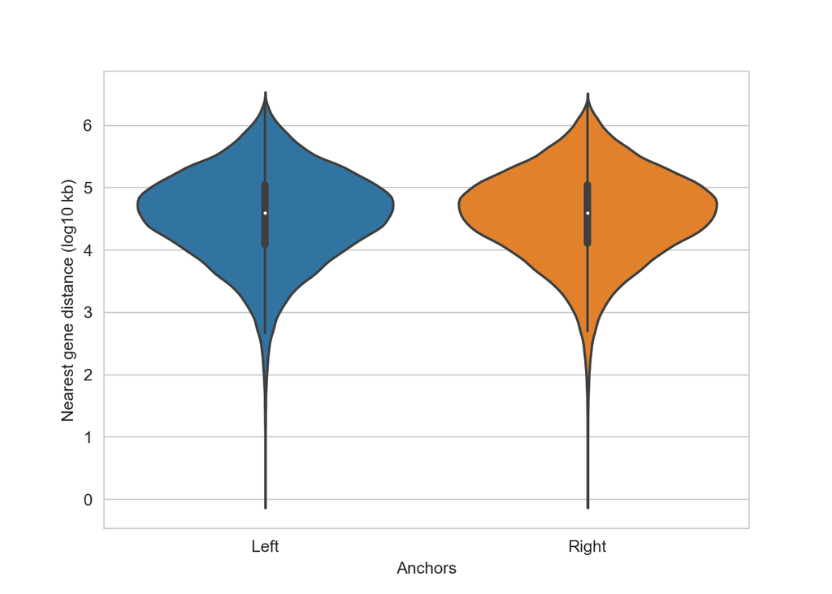

```python
df_left_anchors.rename(columns={'anchor1':'location'},inplace=True)
df_right_anchors.rename(columns={'anchor2':'location'},inplace=True)
df_left_anchors['anchor'] ='Left'
df_right_anchors['anchor'] ='Right'
df_combine_anchors=pd.concat([df_left_anchors,df_right_anchors],axis=0)
df_combine_anchors['nearest_gene_distance'] = np.log10(1+df_combine_anchors['nearest_gene_distance'])
ax = sns.violinplot(x="anchor", y="nearest_gene_distance", data=df_combine_anchors)
plt.xlabel('Anchors')
plt.ylabel('Nearest gene distance (log10 kb)')
plt.show()
```

- Next, we explore whether the distance distribution is different in left and right anchor.

```python
p_value = mannwhitneyu(df_left_anchors['nearest_gene_distance'], \
                      df_right_anchors['nearest_gene_distance'],
                      alternative='two-sided')[1]
print('The distance distribution of left and right anchor are not statistically different, two-sided Mann-Whitney U test P-value=%.4f'%p_value)
```

[output not shown]

# 4 GC content analysis

## 4.1 Preparing the data

- We need to download genome sequence data ([link](http://hgdownload.cse.ucsc.edu/goldenpath/hg19/bigZips/)) for GC content analysis.

```bash
#wget http://hgdownload.cse.ucsc.edu/goldenpath/hg19/bigZips/hg19.fa.gz && gunzip hg19.fa.gz
```

- Calculating the GC content of loop anchors.

```python
genome = Fasta('hg19.fa')
df_left_anchors['GC_content'] = df_left_anchors['location'].apply(\
                                lambda x: (genome[x.split(':')[0]][int(x.split(':')[1].split('-')[0]):\
                                int(x.split(':')[1].split('-')[1])].upper().count('C')+\
                                genome[x.split(':')[0]][int(x.split(':')[1].split('-')[0]):\
                                int(x.split(':')[1].split('-')[1])].upper().count('G'))/ \
                                (int(x.split(':')[1].split('-')[1])-int(x.split(':')[1].split('-')[0])))
df_right_anchors['GC_content'] = df_right_anchors['location'].apply(\
                                lambda x: (genome[x.split(':')[0]][int(x.split(':')[1].split('-')[0]):\
                                int(x.split(':')[1].split('-')[1])].upper().count('C')+\
                                genome[x.split(':')[0]][int(x.split(':')[1].split('-')[0]):\
                                int(x.split(':')[1].split('-')[1])].upper().count('G'))/ \
                                (int(x.split(':')[1].split('-')[1])-int(x.split(':')[1].split('-')[0])))
print('GC content of left anchor is around %.2f to %.2f.'\
                %(df_left_anchors['GC_content'].min(),
                df_left_anchors['GC_content'].max()))
```

```
## GC content of left anchor is around 0.02 to 0.74.
```

```python
print('GC content of right anchor is around %.2f to %.2f.'\
                %(df_right_anchors['GC_content'].min(),
                df_right_anchors['GC_content'].max()))
```

```
## GC content of right anchor is around 0.02 to 0.74.
```

## 4.2 GC content distribution

- Plot the GC content of left and right anchor

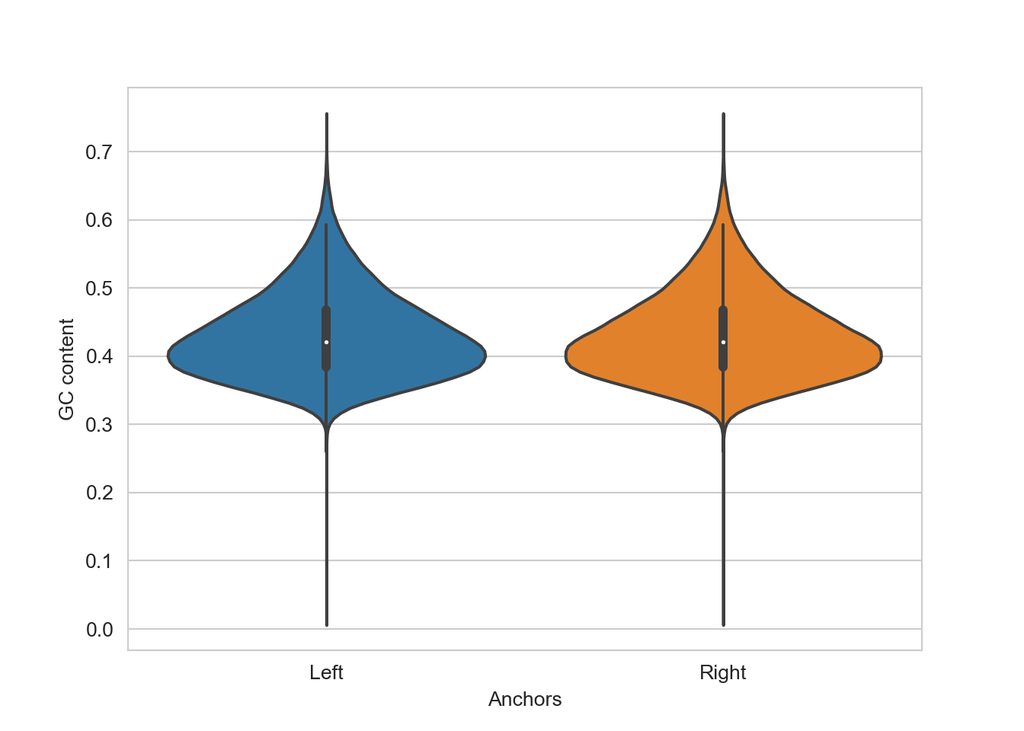

```python
df_combine_anchors=pd.concat([df_left_anchors,df_right_anchors],axis=0)
ax = sns.violinplot(x="anchor", y="GC_content", data=df_combine_anchors)
plt.xlabel('Anchors')
plt.ylabel('GC content')
plt.show()
```

- Next, we explore whether the GC content is different in left and right anchor.

```python
p_value = mannwhitneyu(df_left_anchors['GC_content'], \
                      df_right_anchors['GC_content'],
                      alternative='two-sided')[1]
print('The GC content in left and right anchor is not statistically different by two-sided Mann-Whitney U test, P-value = %.4f'%p_value)
```

```
## The GC content in left and right anchor is not statistically different by two-sided Mann-Whitney U test, P-value = 0.8625
```

# 5 Specificity analysis across cell line

```python
all_loops_CTCF = df_all_loops.loc[(df_all_loops['ChIP'] == 'CTCF')&\
                                    (df_all_loops['qValue']<1e-10)]
all_uniq_loops = all_loops_CTCF[['anchor1','anchor2']].drop_duplicates()
```

```python
nb_cl_by_loop = []
for i in range(len(all_uniq_loops)):
    anchor1, anchor2 = all_uniq_loops.iloc[i].values
    celllines = all_loops_CTCF.loc[(all_loops_CTCF['anchor1']==anchor1)&\
                         (all_loops_CTCF['anchor2']==anchor2)]['cellLine'].values
    uniq_cellines = np.unique(celllines)
    nb_cl_by_loop.append(len(uniq_cellines))
all_uniq_loops['nb_celllines'] = nb_cl_by_loop
all_uniq_loops['specificity']=all_uniq_loops['nb_celllines'].apply(lambda x: 'Rare loops' if x < 5 else ('Others' if x < 10 else 'Common loops'))
all_uniq_loops.head()
```

```
##                         anchor1  ... specificity
## 3665600    chr1:6550000-6555000  ...  Rare loops
## 3665613    chr1:9345000-9350000  ...      Others
## 3665628  chr1:16360000-16365000  ...  Rare loops
## 3665631  chr1:16950000-16955000  ...      Others
## 3665643  chr1:19985000-19990000  ...      Others
##
## [5 rows x 4 columns]
```

- Finally, we plotted the distribution of number of cell lines that a loop exist grouped by cell line specificity.

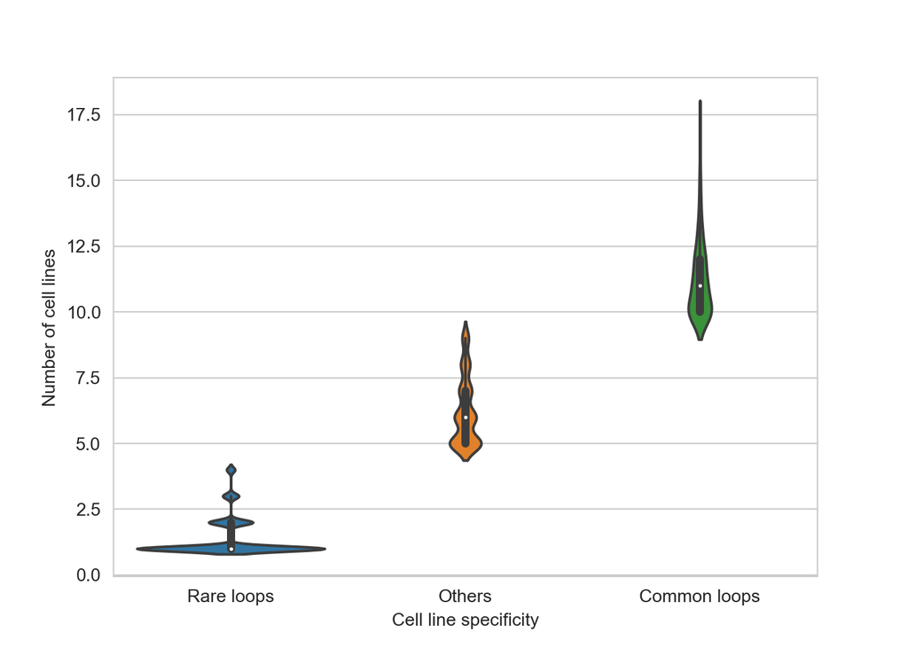

```python
ax = sns.violinplot(x="specificity", y="nb_celllines", data=all_uniq_loops)
plt.xlabel('Cell line specificity')
plt.ylabel('Number of cell lines')
plt.show()
```